# Intro to Forecasting

## Macroeconomic Forecasting for Finance

- Investment banks like Goldman Sachs employ large teams of economic and financial experts to follow and predict the global economic situation to guide investment opportunities for themselves and their clients.
- Reliably forecasting multiple macroeconomic series is one part of this task, and one to which a former Goldman Sachs Chief Economist made important contributions.
- Output Forecasts from BVAR model and commercial forecasters 1982.

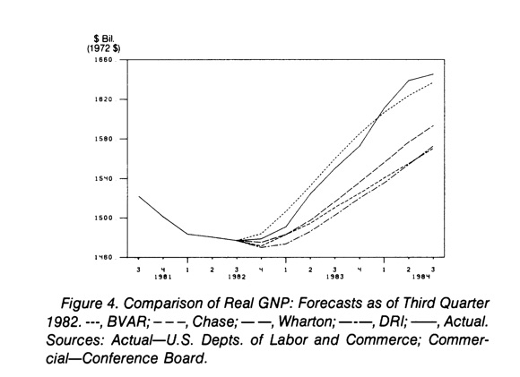

- Goldman Sachs Economic Outlook Report GDP Forecast, Nov 2018

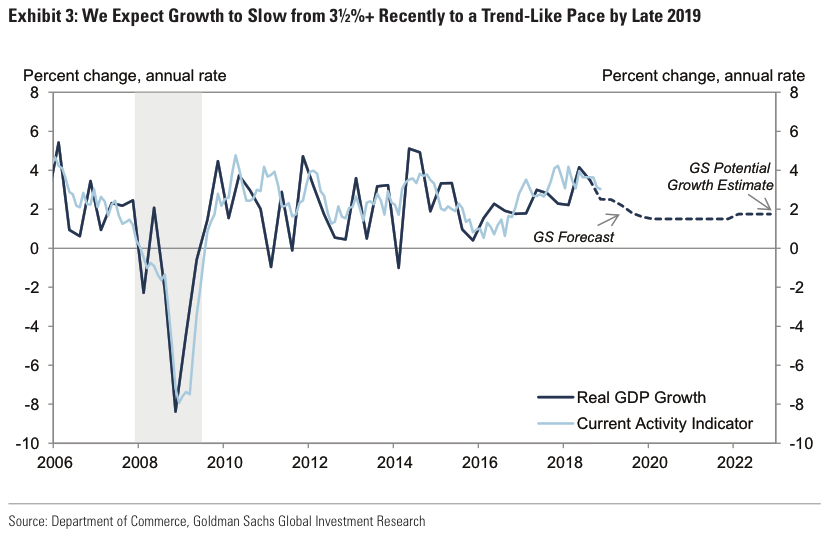

## Web Activity

- Major internet companies like Facebook have both cost and revenue streams closely tied to patterns of traffic to their websites, which are monitored and forecast continuously
- The scale and frequency of the data have led to unique challenges and solutions from their internal forecasting team.

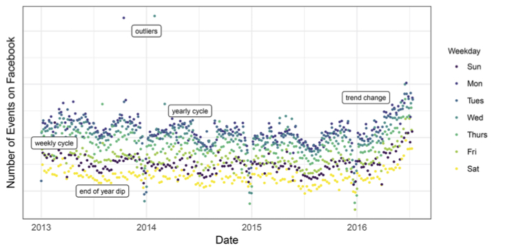

Events created per day on Facebook, with commentary on data features. Source: Taylor & Letham (2018)

## Ad Auctions

- Google derives most of its revenue from advertising sales on keywords, sold by auction.
- This process involves using billions of different characteristics to predict the value of diverse advertisements to contribute to an automated system that generates and applies predictions in real time in an automated fashion without direct human intervention.
- The methods used for this task, also applied by firms like Microsoft and Yahoo, involve innovations not only in the implementation but in the foundational principles of how and why to perform forecasting.

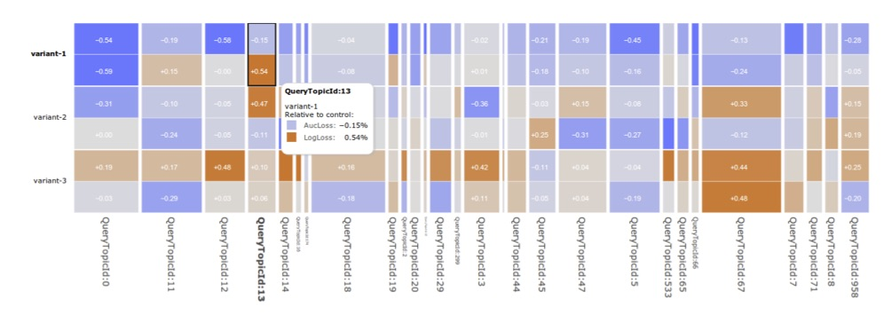

Tool for display of ad click model performance used internally at Google. Source: McMahan et al (2013)

## Monthly Unemployment Releases

- The first Friday of every month, the Bureau of Labor Statistics releases the Employment Situation Report, containing the latest survey data on payrolls and unemployment rates.
- Due to its frequency and economic importance, this is the most tracked regular economic data release
- Policy makers and market participants spend considerable effort to forecast the outcomes, which can move asset returns and policy decisions.
- At the Council of Economic Advisers, which advises the president on economic policy and releases official executive statements regarding economic conditions, staff had a monthly pool to see who could produce the most accurate forecasts.
- In this tradition, this class involves a forecasting competition for these series, where you will apply your knowledge of forecasting principles to compete in an internal forecasting competition to produce the most accurate monthly forecasts.

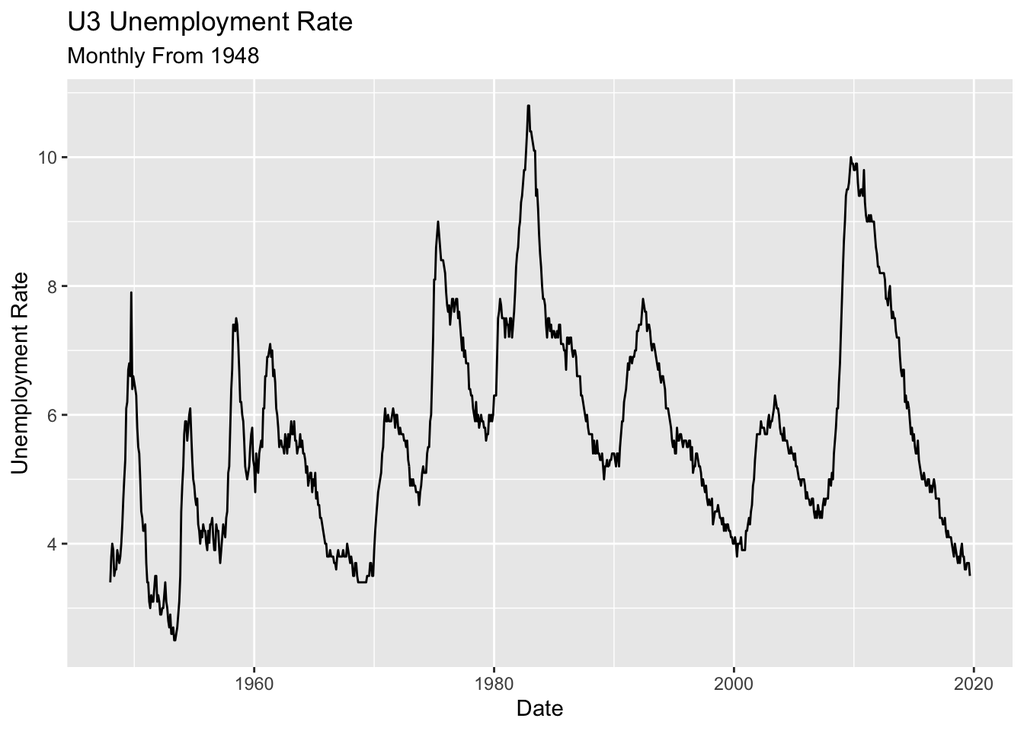

```r
#Let's get the (main) series UNRATE for the unemployment rate.
UNRATE<-fredr(series_id = "UNRATE")
#The jobs series has FRED ID "PAYEMS", for "Payroll Employment Survey", as the numbers are calculated by a survey of employers
#The Employment Situation Report reports growth, so report units as change from last month
PAYEMS<-fredr(series_id = "PAYEMS",units="chg")
#You can also download this series at https://fred.stlouisfed.org/series/PAYEMS
#You can also download this series at https://fred.stlouisfed.org/series/UNRATE
plt<-ggplot(data=UNRATE,mapping=aes(x=date,y=value)) #Plot the data!
plt+geom_line()+
  labs(x="Date",y="Unemployment Rate",
       title="U3 Unemployment Rate",
       subtitle="Monthly From 1948")
```

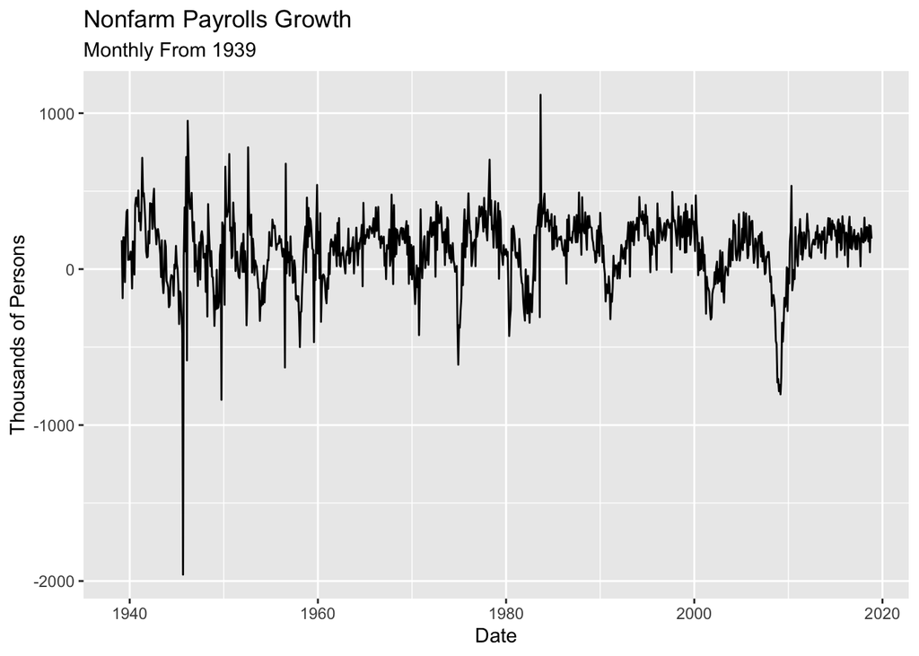

```r
pplt<-ggplot(data=PAYEMS[2:959,],mapping=aes(x=date,y=value)) #Plot the data!
pplt+geom_line()+
  labs(x="Date",y="Thousands of Persons",
       title="Nonfarm Payrolls Growth",
       subtitle="Monthly From 1939")
```

## For next class

- Take a look at the textbook Chapters 1 and 2
- Sign up for an account at https://www.kaggle.com
- Bring your laptops
  - We will be exploring R, Kaggle, and working with data!